# BIOS 611 HW3 Exploratory Analysis, tibbles, and data import (Chapters 7, 10, and 11.2)

Lang Li

`2018-09-17 20:19:48 EDT

This homework is due `Monday September 17th by 6pm`.  
Both `.Rmd` and `.html` files should be submitted.  
(This set of exercise is mostly taken from R for Data Science by Garrett Grolemund and Hadley Wickham.)

# Exercise 1

1. Explore the distribution of `price`. Do you discover anything unusual or surprising? (Hint: Carefully think about the `binwidth` and make sure you try a wide range of values.)

   Answer:

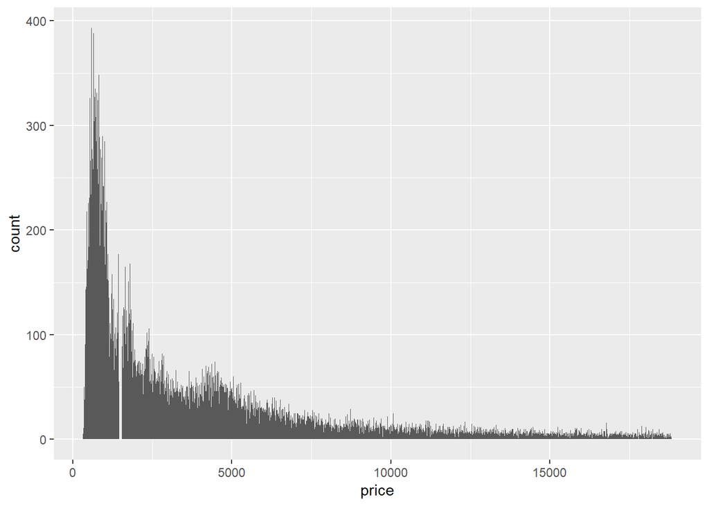

   ```r
   ggplot(diamonds,aes(price))+geom_histogram(binwidth = 10)
   ```

It seems that there is a gap between 0 and 2500. So we want to explore it more:

[output not shown]

So we found that the gap is at 1500. There is no diamond priced at 1500! Interesting. Also, we find a lot of diamond is priced between 500 and 1000.

2. Compare and contrast `coord_cartesian()` vs `xlim()` or `ylim()` when zooming in on a histogram.

   Answer:

`coord_cartesian()`

[output not shown]

`xlim()` and `ylim()`

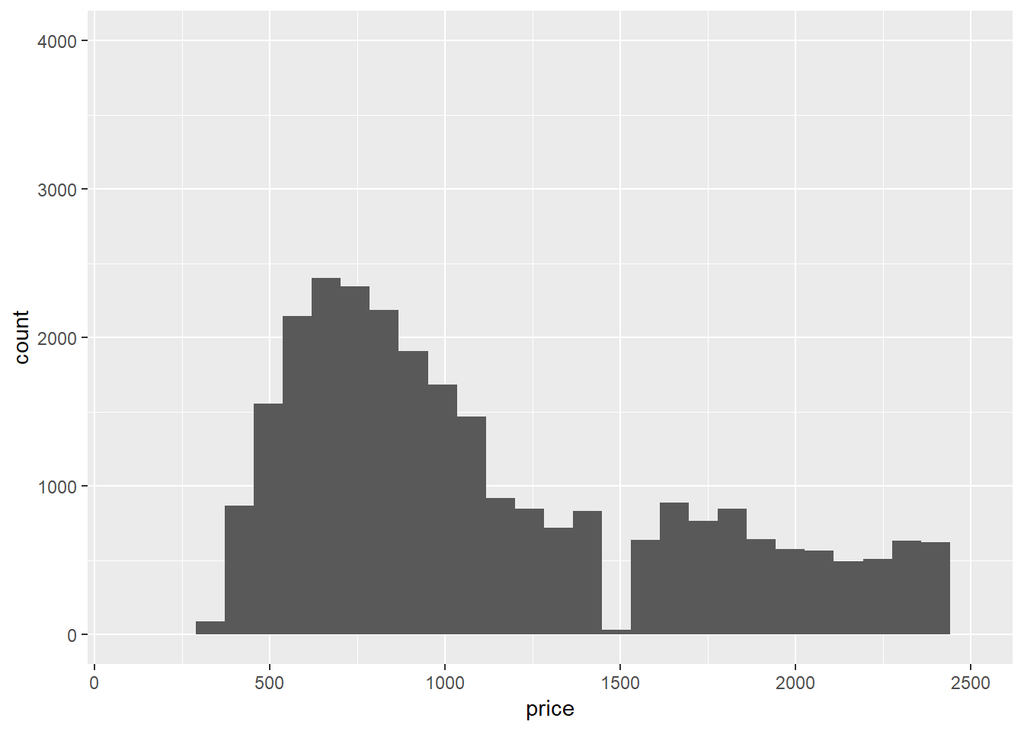

```r
ggplot(diamonds,aes(x = price)) +
  geom_histogram() +
  xlim(100, 2500) +
  ylim(0, 4000)
```

So they both zoom in to show the specific area, which is their similarity. However, as we can see, the graph looks very different. I believe that the `xlim()` and `ylim()` give the accurate count. And, I am not sure why the`coord_cartesian()` looks that way… I guess since it is a zoom it, it compares the relative frequency.

# Exercise 2

1. There are several ways of getting complete data (i.e. ignoring the incomplete cases). Using each of the following functions, try to get complete data.

   Answer:

   ```r
   # Use this dataset
   data.a = data.frame(no = 1:5, abc = letters[1:5], ABC = LETTERS[11:15], rand = rnorm(5))
   data.a[3,3] <- data.a[2,1] <- NA
   data.a
   ```

   ```
   ##   no abc  ABC       rand
   ## 1  1   a    K  0.5383107
   ## 2 NA   b    L  1.2153237
   ## 3  3   c <NA> -0.0150075
   ## 4  4   d    N  0.4063418
   ## 5  5   e    O  0.4371300
   ```

   ```r
   # A. na.omit
   na.omit(data.a)
   ```

   ```
   ##   no abc ABC      rand
   ## 1  1   a   K 0.5383107
   ## 4  4   d   N 0.4063418
   ## 5  5   e   O 0.4371300
   ```

   ```r
   # B. complete.cases
    data.a[complete.cases(data.a),]
   ```

   ```
   ##   no abc ABC      rand
   ## 1  1   a   K 0.5383107
   ## 4  4   d   N 0.4063418
   ## 5  5   e   O 0.4371300
   ```

2. What does `na.rm = TRUE` do in `mean()` and `sum()`?

   Answer: This will remove the `NA` values prior to calculating the sum and mean.
3. We want to see if there is a pattern of delay according to the scheduled departure time. Criticize the following graph. (If you cannot notice the problem, go back to the example in the note and see why they used `mutate` function. Note only a small sample was used for convenience.)

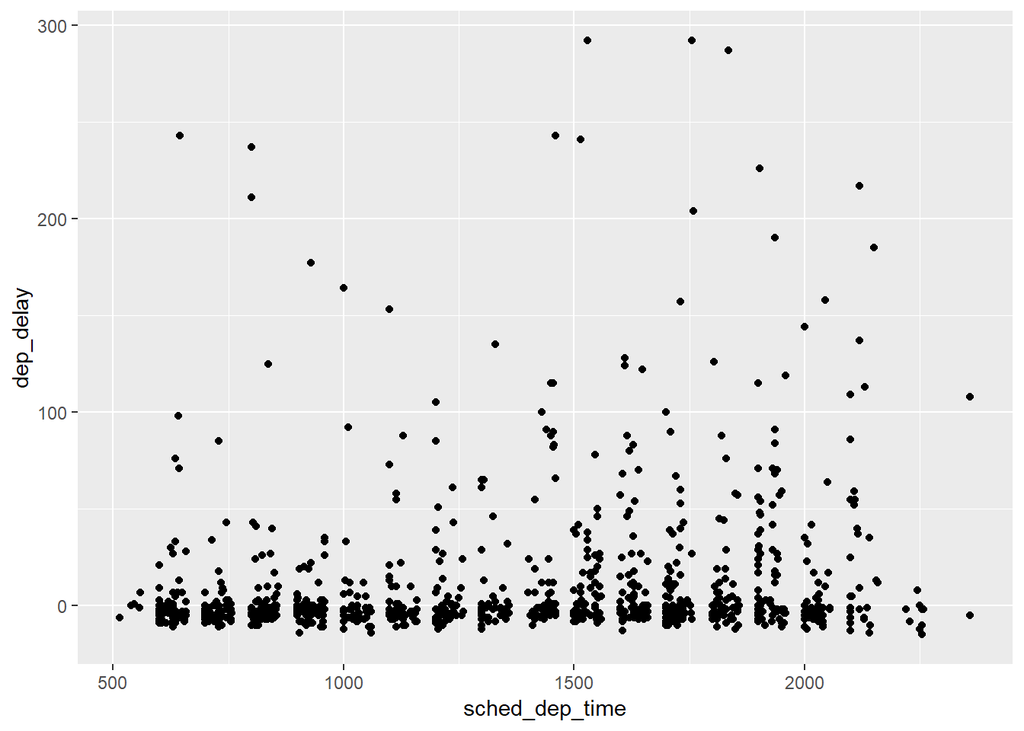

   ```r
   set.seed(1)
   newdata = sample_n(nycflights13::flights, 1000)
   newdata %>% ggplot(aes(sched_dep_time, dep_delay)) + geom_point()
   ```

   Answer:

# Exercise 3

1. Use what you’ve learned to improve the visualisation of the departure times of cancelled vs. non-cancelled flights. (Hint: normalize them.)

   Answer: So we want to normalized it into its hour form (1340 = 13.67 for example):

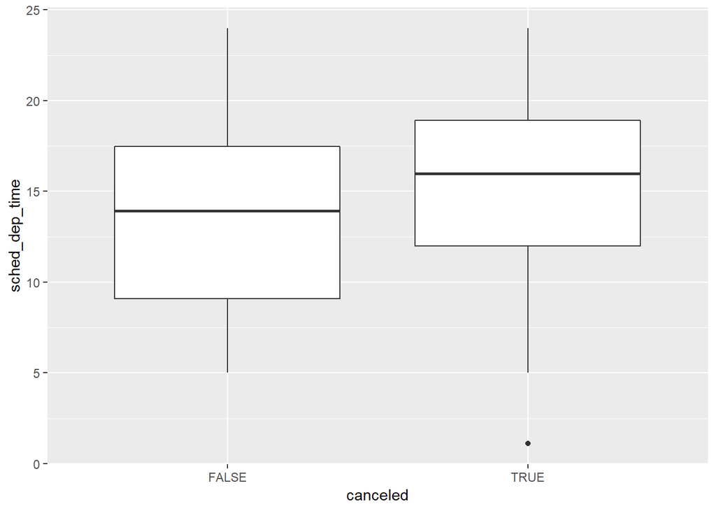

   ```r
   flights %>%
     mutate(canceled = is.na(dep_time),sched_hour = sched_dep_time %/% 100,sched_min = sched_dep_time %% 100,sched_dep_time = sched_hour + sched_min / 60) %>%
     ggplot() +
     geom_boxplot(mapping = aes(y = sched_dep_time, x = canceled))
   ```

2. What variable in the diamonds dataset is most important for predicting the price of a diamond? How is that variable correlated with cut? Why does the combination of those two relationships lead to lower quality diamonds being more expensive?